# Informe Hito 1

Grupo 15

## Integrantes

- Daniel Díaz
- Vanessa Gaete
- Christopher Marín
- Valentina Vásquez

## Dataset

Información sobre ítems pertenecientes al juego Animal Crossing: New Horizons. Disponible en [kaggle](https://www.kaggle.com/datasets/jessicali9530/animal-crossing-new-horizons-nookplaza-dataset).

## Índice

- Motivación
- Caracterización del dataset
  - Atributos
  - Valores nulos
- Análisis de datos
  - ¿Hay objetos que salga más caro venderlo que comprarlo?
  - ¿Hay objetos que se puedan vender pero no comprar?
  - Correlación entre características numéricas
  - Distribución de muestras por categoría
  - Relación precio-categoría
  - Relación precio-estilo
- Problemas y desafíos
- Aportes de cada integrante

# Motivación

Animal Crossing: New Horizons es un juego de Nintendo que consiste en una simulación de vida, donde el jugador tiene libertad de jugar como él desee ya que es de tipo abierto, es decir, sin objetivos definidos. Tal como en la vida real, el jugador es dueño de una casa de la que se debe preocupar, amoblar, decorar, ampliar. También puede interactuar con vecinos, personalizar la aldea, comprar, vender, hacer trueques entre jugadores y recolectar objetos.

El trabajo se enfocará en la compra, venta, trueques y recolección de objetos del juego. Se tiene un dataset con la información de cada uno de los objetos y sus características. Estos datos son muy relevantes en el sentido de que los jugadores están muy orientados al coleccionismo, convirtiéndose en unas de las razones que genera más atracción del juego.

Otra característica importante del juego es poder hacer trueques entre jugadores, ya que les permite obtener objetos difíciles de conseguir. Esto crea un flujo de dinero tanto dentro como fuera del juego, el cual se buscará estudiar también en este proyecto.

# Caracterización del dataset

```python
import pandas as pd
import numpy as np

#Carga los datos
ac_data = pd.read_csv('animal-crossing-items.csv')
ac_data
```

|  | Name | Category | Variation | Color 1 | Color 2 | Size | DIY | Buy | Sell | Miles Price | ... | Source Notes | Interact | Catalog | Style | Label Themes | HHA Category 1 | HHA Category 2 | HHA Series | HHA Set | Tag |
| --- | --- | --- | --- | --- | --- | --- | --- | --- | --- | --- | --- | --- | --- | --- | --- | --- | --- | --- | --- | --- | --- |
| 0 | 3D glasses | Accessories | White | White | Colorful | 1x1 | No | 490 | 122 | NaN | ... | Available from Able Sisters shop only | No | For sale | Active | party | None | None | None | None | None |
| 1 | 3D glasses | Accessories | Black | Black | Colorful | 1x1 | No | 490 | 122 | NaN | ... | Available from Able Sisters shop only | No | For sale | Active | party | None | None | None | None | None |
| 2 | bandage | Accessories | Beige | Beige | White | 1x1 | No | 140 | 35 | NaN | ... | Available from either Mable's temporary shop o... | No | For sale | Active | outdoorsy; comfy; sporty | None | None | None | None | None |
| 3 | beak | Accessories | Yellow | Yellow | Yellow | 1x1 | No | 490 | 122 | NaN | ... | Available from either Mable's temporary shop o... | No | For sale | Cute | fairy tale; party; theatrical | None | None | None | None | None |
| 4 | birthday shades | Accessories | Yellow | Yellow | Red | 1x1 | No | -1 | 620 | NaN | ... | No Notes | No | Not for sale | Gorgeous | party | None | None | None | None | None |
| ... | ... | ... | ... | ... | ... | ... | ... | ... | ... | ... | ... | ... | ... | ... | ... | ... | ... | ... | ... | ... | ... |
| 14337 | yellow playroom wall | Wallpapers | None | Yellow | Yellow | Full | No | 2540 | 635 | NaN | ... | No Notes | No | For sale | None | NaN | child's room | fancy | None | None | Toy Walls |
| 14338 | yellow quilt wall | Wallpapers | None | Yellow | White | Full | No | 2150 | 537 | NaN | ... | No Notes | No | For sale | None | NaN | fancy | child's room | None | None | Dollhouse Walls |
| 14339 | yellow simple-cloth wall | Wallpapers | None | Beige | Yellow | Full | No | 750 | 187 | NaN | ... | No Notes | No | For sale | None | NaN | child's room | living room | None | None | Simple Walls |
| 14340 | yellow-paint wall | Wallpapers | None | Yellow | Yellow | Full | No | 1600 | 400 | NaN | ... | No Notes | No | For sale | None | NaN | fancy | child's room | None | None | Stucco Walls |
| 14341 | yellow-striped wall | Wallpapers | None | Yellow | Beige | Full | No | 1520 | 380 | NaN | ... | No Notes | No | For sale | None | NaN | fancy | child's room | None | None | Stripe Walls |

14342 rows × 21 columns

```python
print("Dimesiones del dataset: ", ac_data.shape)
columns=list(ac_data.columns.values)
print("Columnas del dataset:", columns)
```

```
Dimesiones del dataset:  (14342, 21)
Columnas del dataset: ['Name', 'Category', 'Variation', 'Color 1', 'Color 2', 'Size', 'DIY', 'Buy', 'Sell', 'Miles Price', 'Source', 'Source Notes', 'Interact', 'Catalog', 'Style', 'Label Themes', 'HHA Category 1', 'HHA Category 2', 'HHA Series', 'HHA Set', 'Tag']
```

## Atributos

El dataset se compone de 14342 filas correspondientes a objetos existentes en el juego, y 21 columnas que contienen información asociada a estos. Cada objeto posee los siguientes atributos:

- Name: Nombre del ítem, este nombre no es necesariamente el que se muestra en el juego.
- Category: Categoría a la que el ítem corresponde, existen varias categorías para las distintas piezas de ropa, muebles o piezas de arte.
- Variation: Variación del ítem con respecto a otros del mismo nombre. Puede indicar color, patrón, contenido, entre otras cosas.
- Color 1: Primer color del ítem.
- Color 2: Segundo color del ítem.
- Size: Tamaño del ítem en cuadrícula de objetos.
- DIY: Si el ítem se puede crear en la mesa de construcción o no.
- Buy: Precio de compra en bayas, moneda principal del juego.
- Sell: Precio de venta en bayas, moneda principal del juego.
- Miles Price: Precio de compra en millas, moneda secundaria del juego.
- Source: Forma de obtención del ítem, puede ser una actividad, una tienda o un personaje que lo venda.
- Source Notes: Notas extra sobre la forma de obtención, como periodos de disponibilidad o condiciones de desbloqueo.
- Interact: Formas de interarcción disponibles, puede ser directamente interactuable o a través de otro ítem como un basurero o armario.
- Catalog: Si el ítem está presente en el catálogo del juego, marcado para la venta o no.
- Style: Estilo de las piezas de ropa, utilizado junto con la temática para comprobar la compatibilidad de los *outfits*.
- Label Themes: Temáticas de las piezas de ropa, utilizado junto con el estilo para comprobar la compatibilidad de los *outfits*.
- HHA Category 1: Primer concepto asociado al mueble u objeto decorativo, utilizado por la Happy Home Academy para puntuar el diseño de la casa.
- HHA Category 2: Segundo concepto asociado al mueble u objeto decorativo, utilizado por la Happy Home Academy para puntuar el diseño de la casa.
- HHA Series: Serie del mueble u objeto decorativo, utilizado por la Happy Home Academy para puntuar el diseño de la casa.
- HHA Set: Conjunto al que pertenece el mueble u objeto decorativo, utilizado por la Happy Home Academy para puntuar el diseño de la casa.
- Tag: Etiquetas aplicables a los ítems.

## Valores Nulos

A continuación se cuentan la cantidad de `NaN` y `None` para cada una de las columnas.

Se puede notar que hay muchas muestras con `NaN` en la columna de `Miles Price`. Los Miles o Millas son otra divisa del juego, en este caso, los objetos que tienen un `NaN` en esa columna no se pueden comprar con Miles.

Por otra parte, en la mayoría de los casos que aparecen `None`s es porque son atributos que no aplican a dicho objeto debido a su categoría. Por ejemplo los `HHA` que corresponden a clasificación de inmuebles y decoraciones para el hogar no aplican para prendas de ropa.

```python
print("Cantidad de NaN's por columna: ", ac_data.isna().sum(), "\n")
```

```
Cantidad de NaN's por columna:  Name                  0
Category              0
Variation             0
Color 1               0
Color 2               0
Size                  0
DIY                   0
Buy                   0
Sell                  0
Miles Price       14187
Source                0
Source Notes          0
Interact              0
Catalog               0
Style                 0
Label Themes       9763
HHA Category 1        0
HHA Category 2        0
HHA Series            0
HHA Set               0
Tag                   0
dtype: int64
```

```python
print("Nones por columna\n")
for column in columns:
    try:
        result=ac_data[column].value_counts()["None"]
    except:
        result= 0

    print(column, ": ", result )
```

```
Nones por columna

Name :  0
Category :  0
Variation :  2312
Color 1 :  600
Color 2 :  604
Size :  0
DIY :  0
Buy :  0
Sell :  0
Miles Price :  0
Source :  0
Source Notes :  0
Interact :  0
Catalog :  0
Style :  9762
Label Themes :  0
HHA Category 1 :  9108
HHA Category 2 :  11622
HHA Series :  12920
HHA Set :  14066
Tag :  8797
```

# Análisis de Datos

## ¿Hay objetos que salga más caro venderlo que comprarlo?

En el juego es muy importante generar dinero para así poder comprar y coleccionar distintas clases de objetos. Una pregunta interesante es saber si existen objetos que se puedan vender por un precio mayor que se pagó para comprarlo. De la tabla que está a continuación se puede ver que solo hay 6 objetos que cumplen con esta característica y la mayoría de ellos no generan muchas ganancias, además de tener condiciones específicas de creación y venta.

```python
ac_data[ac_data.Buy != -1][ac_data.Sell > ac_data.Buy].reset_index()
```

|  | index | Name | Category | Variation | Color 1 | Color 2 | Size | DIY | Buy | Sell | ... | Source Notes | Interact | Catalog | Style | Label Themes | HHA Category 1 | HHA Category 2 | HHA Series | HHA Set | Tag |
| --- | --- | --- | --- | --- | --- | --- | --- | --- | --- | --- | --- | --- | --- | --- | --- | --- | --- | --- | --- | --- | --- |
| 0 | 7394 | apple | Other Items | None | None | None | 1x1 | No | 400 | 500 | ... | No Notes | No | For sale | None | NaN | None | None | None | None | None |
| 1 | 7440 | cherry | Other Items | None | None | None | 1x1 | No | 400 | 500 | ... | No Notes | No | For sale | None | NaN | None | None | None | None | None |
| 2 | 7507 | orange | Other Items | None | None | None | 1x1 | No | 400 | 500 | ... | No Notes | No | For sale | None | NaN | None | None | None | None | None |
| 3 | 7528 | peach | Other Items | None | None | None | 1x1 | No | 400 | 500 | ... | No Notes | No | For sale | None | NaN | None | None | None | None | None |
| 4 | 7530 | pear | Other Items | None | None | None | 1x1 | No | 400 | 500 | ... | No Notes | No | For sale | None | NaN | None | None | None | None | None |
| 5 | 14316 | wedding-party wall | Wallpapers | None | None | None | Full | No | 1750 | 4375 | ... | No Notes | No | Not for sale | None | NaN | party | expensive | wedding | None | Cloth Walls |

6 rows × 22 columns

## ¿Hay objetos que se puedan vender pero no comprar?

Una pregunta aún mas interesante es saber si hay objetos por los que no haya que pagar para obtenerlos pero que sí se puedan vender.

```python
ac_data[ac_data.Buy == -1][ac_data.Sell > 0][['Name', "Category", "Buy", "Sell", "DIY", "Source", "Style", "Tag"]].reset_index()
```

|  | index | Name | Category | Buy | Sell | DIY | Source | Style | Tag |
| --- | --- | --- | --- | --- | --- | --- | --- | --- | --- |
| 0 | 4 | birthday shades | Accessories | -1 | 620 | No | Birthday | Gorgeous | None |
| 1 | 5 | birthday shades | Accessories | -1 | 620 | No | Birthday | Gorgeous | None |
| 2 | 6 | birthday shades | Accessories | -1 | 620 | No | Birthday | Gorgeous | None |
| 3 | 7 | birthday shades | Accessories | -1 | 620 | No | Birthday | Gorgeous | None |
| 4 | 30 | candy-skull mask | Accessories | -1 | 800 | No | Gulliver | Gorgeous | None |
| ... | ... | ... | ... | ... | ... | ... | ... | ... | ... |
| 5738 | 14314 | underwater wall | Wallpapers | -1 | 8600 | Yes | Crafting | None | Special Cool Nature Walls |
| 5739 | 14330 | wild-wood wall | Wallpapers | -1 | 1800 | Yes | Crafting | None | Wood Walls |
| 5740 | 14331 | wooden-knot wall | Wallpapers | -1 | 1800 | Yes | Crafting | None | Wood Walls |
| 5741 | 14332 | wooden-mosaic wall | Wallpapers | -1 | 1800 | Yes | Crafting | None | Wood Plank Walls |
| 5742 | 14333 | woodland wall | Wallpapers | -1 | 1380 | Yes | Crafting | None | Nature Walls |

5743 rows × 9 columns

## ¿Cuál es la correlación entre las características numéricas?

Para este dataset no es viable generar un heatmap de correlación debido a que los datos en general no son numéricos, en particular hay apenas unas 3 columnas de tipo numéricos, lo que hace difícil conseguir conclusiones a partir de sus relaciones. Aún así, se hizo una matriz de correlación entre las columnas numéricas para saber si se podía sacar alguna conclusión a partir de esto. El resultado arroja que entre el precio de venta y precio en Miles hay una relación cercana a ser directamente proporcional. Algo semejante pasa con los precios de compra y venta.

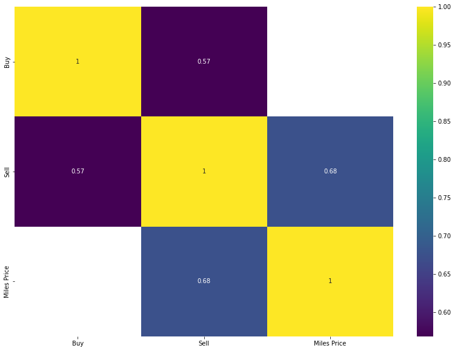

```python
import matplotlib.pyplot as plt
import seaborn as sns


plt.figure(figsize=(14, 10))
sns.heatmap(ac_data.corr(), cmap='viridis', annot=True)
```

## ¿Cómo se distribuyen las muestras según categorías?

A continuación se presenta un gráfico de barras con la frecuencia de muestras para cada una de las categorías. El resultado indica que hay muchos más ítems en el juego correspondientes a fotos y artículos de hogar que del resto de categorías. Por otro lado los objetos menos frecuentes corresponden a arte.

```
<BarContainer object of 24 artists>
```

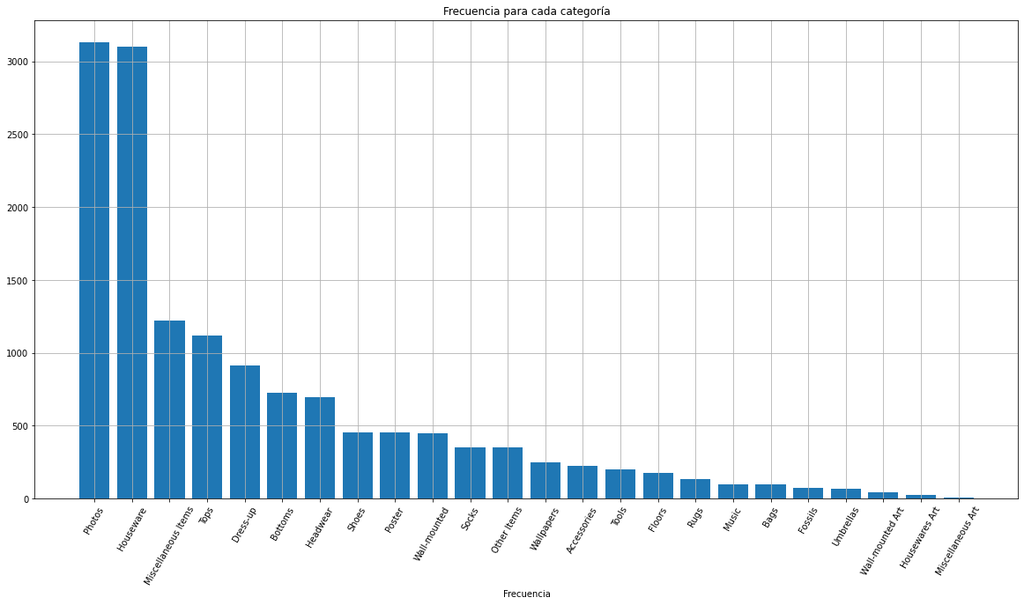

```python
plt.figure(figsize=(20, 10))
plt.xticks(rotation=60)
plt.title("Frecuencia para cada categoría")
plt.xlabel("Categoría")
plt.xlabel("Frecuencia")

categories = np.array(list(ac_data["Category"].value_counts().index))
frequencies = np.array(list(ac_data["Category"].value_counts()))

plt.grid()
plt.bar(categories, frequencies)
```

## ¿Cómo se relacionan los precios con la categoría del objeto?

Para responder a esta interrogante y además estudiar outliers se grafica el boxplot a continuación. Es fácil notar que hay dos outliers para la categoría de artículos para la cabeza, correspondientes a dos objetos que tienen un precio mayor a 800.000.

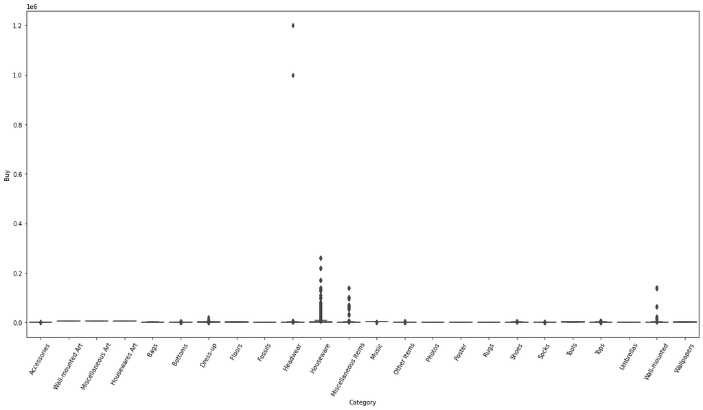

```python
plt.figure(figsize=(20, 10))
plt.xticks(rotation=60)
ax = sns.boxplot(x="Category", y="Buy", data=ac_data)
```

Se busca saber cuáles son estos dos objetos, pues podrían ser especiales y eso es de gran interés para un jugador. Hay un objeto que cuesta 1.000.000 bayas correspondiente a una corona y otro que corresponde a una corona real por 1.200.000 bayas.

[figure not shown]

```python
ac_data[ac_data.Buy > 800000 ]
```

|  | Name | Category | Variation | Color 1 | Color 2 | Size | DIY | Buy | Sell | Miles Price | ... | Source Notes | Interact | Catalog | Style | Label Themes | HHA Category 1 | HHA Category 2 | HHA Series | HHA Set | Tag |
| --- | --- | --- | --- | --- | --- | --- | --- | --- | --- | --- | --- | --- | --- | --- | --- | --- | --- | --- | --- | --- | --- |
| 2389 | crown | Headwear | Gold | Yellow | Yellow | 1x1 | No | 1000000 | 250000 | NaN | ... | Available from Able Sisters shop only | No | For sale | Gorgeous | fairy tale; formal; party; theatrical | None | None | None | None | None |
| 2758 | royal crown | Headwear | Red | Red | Yellow | 1x1 | No | 1200000 | 300000 | NaN | ... | Available from Able Sisters shop only | No | For sale | Gorgeous | fairy tale; party; theatrical | None | None | None | None | None |

2 rows × 21 columns

Como las dos coronas no permiten estudiar bien los otros ítems, se filtran.

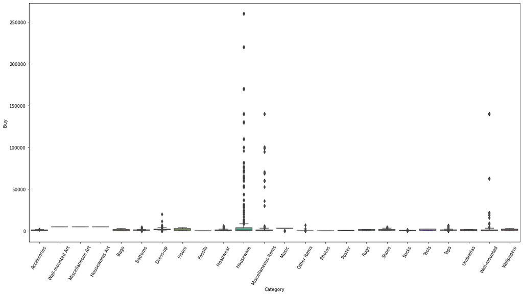

```python
ac_data_filtered = ac_data[800000 > ac_data.Buy ]
plt.figure(figsize=(20, 10))
plt.xticks(rotation=60)
ax = sns.boxplot(x="Category", y="Buy", data=ac_data_filtered)
```

Aún así, siguen habiendo muchos outliers en los artículos de casa que entorpecen la visualización, por lo que se limpian los objetos que tengan un precio mayor a 15.000 y se vuelva a hacer un boxplot.

Se concluye que la categoría con el mayor rango de precios corresponde a la de artículos de casa, llegando a tener incluso los precios más altos. Los objetos de categoría `fósiles`, `fotos` y `otros items` son los que oscilan entre los precios más bajos. Por otro lado, los de categoría `música`, `fotos`, `wall-mounted art`, `miscellaneous art`, y `housewares art` tienen precios estables que no varían.

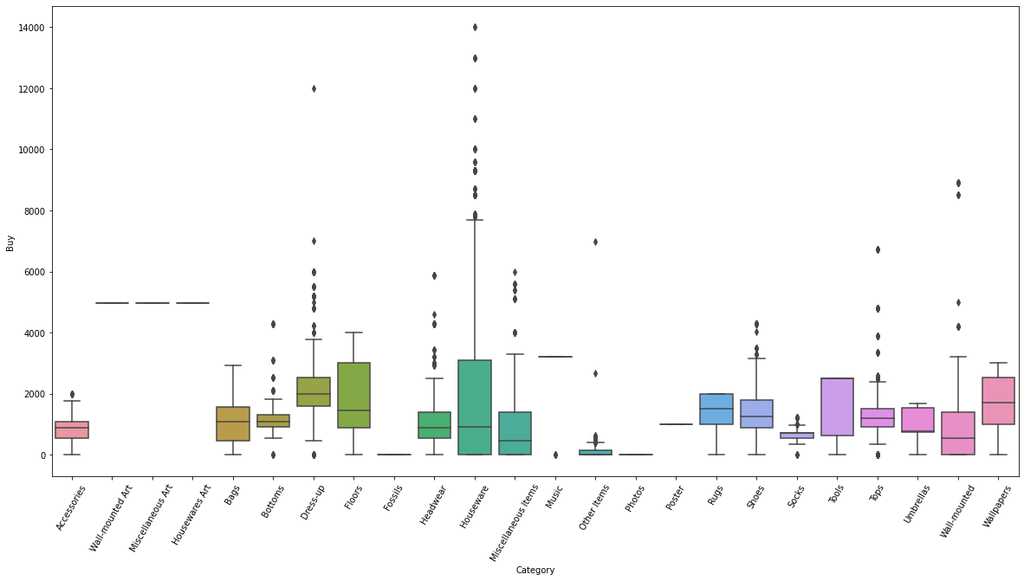

```python
ac_data_filtered = ac_data[15000 > ac_data.Buy ]
plt.figure(figsize=(20, 10))
plt.xticks(rotation=60)
ax = sns.boxplot(x="Category", y="Buy", data=ac_data_filtered)
```

## ¿Cómo se relaciona el precio de compra con el estilo del objeto?

De forma similar a lo anterior, se estudia la relación entre los precios de compra y el estilo del objeto, filtrando los objetos que cuestan más de 15.000 para no tener los mismos outliers de antes que no permitían visualizar bien la información.

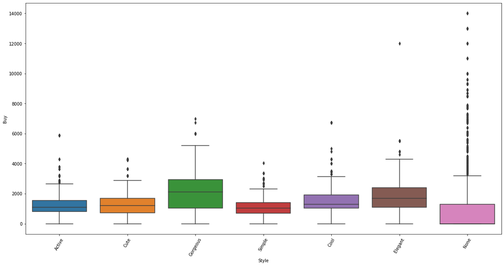

```python
ac_data_filtered = ac_data[15000 > ac_data.Buy ]
plt.figure(figsize=(20, 10))
plt.xticks(rotation=60)
ax = sns.boxplot(x="Style", y="Buy", data=ac_data_filtered)
```

# Problemas y desafíos

Dado que el dataset consiste en los objetos del juego etiquetados y con la información de sus distintas características, algunas interrogantes que surgen y que interesa investigar es:

- ¿Es posible crear un modelo predictivo que sea capaz de clasificar un objeto basado en sus características?
- ¿Cuál es la forma más rentable de generar dinero en el juego? ¿Qué objetos conviene conseguir o crear? ¿Cómo conseguirlos?
- Ya que estamos hablando de un tipo de trueque en el juego, ¿Es posible que le afecten problemas de índole económico como una inflación o alguna situación del mundo real como una guerra, crisis, desastre natural, etc?

# Aportes de cada integrante

## Daniel Díaz

- Preparación de presentación
- Grabación del video

## Vanessa Gaete

- Gráficos y exploración de datos
- Redacción de informe

## Christopher Marín

- Preparación de dataset
- Explicación de dataset

## Valentina Vásquez

- Preparación de presentación
- Exploración de datos

Link del video de presentación: https://youtu.be/xqPGWe1W7aI